# Predicting Physical Activity Correctness

Agustin González-Quel

December, 24th 2016

# Predicting Physical Activity Correctness

The goal of the project is to predict the manner in which they did the exercise. This is the “classe” variable in the training set.

This report is based on data from accelerometers on the belt, forearm, arm, and dumbell of 6 participants. They were asked to perform barbell lifts correctly and incorrectly in 5 different ways. More information is available from the website here: (http://groupware.les.inf.puc-rio.br/har)

## Required Libraries

```r
library(knitr)
library(caret)
library(randomForest)
library(rattle)
```

## Data acquisition and cleaning

We download the data to a local file to work with:

```r
trainFile <- "./pml-training.csv"
testFile <- "./pml-testing.csv"
trainingData <- read.csv(trainFile, na.strings=c("NA","#DIV/0!",""))
testingData <- read.csv(testFile, na.strings=c("NA","#DIV/0!",""))
dim(trainingData)
```

```
## [1] 19622   160
```

```r
dim(testingData)
```

```
## [1]  20 160
```

Both the training data and test data contain 160 columns of information. We are going to clean the data. We will preserve the classe variable so it is not affected by the cleaning

At this point we clean the data, removing near zero variance variables

```r
keepClasse <- trainingData$classe
KeepProblemId <- testingData$problem_id
nzIndex <- nearZeroVar(trainingData, saveMetrics=TRUE)
trainingData <- trainingData[,nzIndex$nzv==FALSE]
```

Then we remove NA values and collumns that are not meaningful

```r
trainingData <- trainingData[, colSums(is.na(trainingData)) == 0]
toRemove <- grepl("^X|timestamp|window", names(trainingData))
trainingData <- trainingData[, !toRemove]
trainingData <- trainingData[, sapply(trainingData, is.numeric)]
trainingData$classe <- keepClasse
dim(trainingData)
```

```
## [1] 19622    53
```

And finally, the dataset has only 53 variables

## Model selection and training

We split the training data into train and validation sets

```r
set.seed(15767) # For reproducibile purpose
trainSet <- createDataPartition(trainingData$classe, p=0.70, list=F)
actualTrain <- trainingData[trainSet, ]
actualValidate <- trainingData[-trainSet, ]
```

### Model based on Decision Tree algorithm

```r
modelDT <- train(classe ~., method="rpart", data = actualTrain )
predictDT <- predict(modelDT, actualValidate)
```

We can have a look at the model graphically

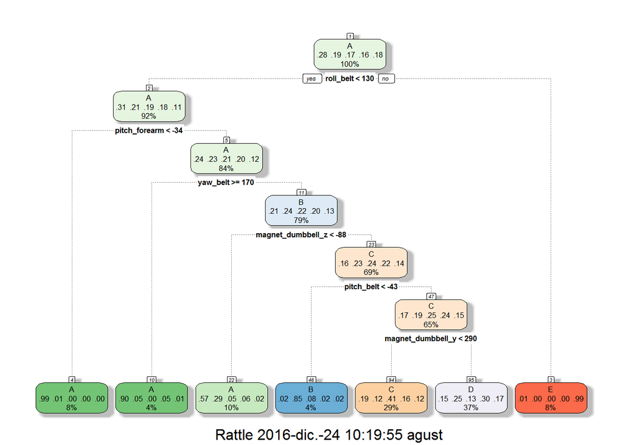

```r
fancyRpartPlot(modelDT$finalModel)
```

And check the correctness of the model

```r
confusionMatrix(predictDT, actualValidate$classe)
```

```
## Confusion Matrix and Statistics
##
##           Reference
## Prediction    A    B    C    D    E
##          A 1036  181   27   71   17
##          B    2  197   27    8    6
##          C  330  191  676  281  214
##          D  302  570  296  604  351
##          E    4    0    0    0  494
##
## Overall Statistics
##
##                Accuracy : 0.511
##                  95% CI : (0.4981, 0.5238)
##     No Information Rate : 0.2845
##     P-Value [Acc > NIR] : < 2.2e-16
##
##                   Kappa : 0.3909
##  Mcnemar's Test P-Value : < 2.2e-16
##
## Statistics by Class:
##
##                      Class: A Class: B Class: C Class: D Class: E
## Sensitivity            0.6189  0.17296   0.6589   0.6266  0.45656
## Specificity            0.9297  0.99094   0.7909   0.6913  0.99917
## Pos Pred Value         0.7778  0.82083   0.3995   0.2845  0.99197
## Neg Pred Value         0.8599  0.83313   0.9165   0.9043  0.89085
## Prevalence             0.2845  0.19354   0.1743   0.1638  0.18386
## Detection Rate         0.1760  0.03347   0.1149   0.1026  0.08394
## Detection Prevalence   0.2263  0.04078   0.2875   0.3607  0.08462
## Balanced Accuracy      0.7743  0.58195   0.7249   0.6589  0.72786
```

### Model based on Random Forest

```r
modelRF <- randomForest(classe ~ ., data=actualTrain)
predictRF <- predict(modelRF, actualValidate)
```

Using the Confusion Matrix we can check the correctness of the model

```r
confusionMatrix(predictRF, actualValidate$classe)
```

```
## Confusion Matrix and Statistics
##
##           Reference
## Prediction    A    B    C    D    E
##          A 1674    4    0    0    0
##          B    0 1130    4    0    0
##          C    0    5 1021    8    0
##          D    0    0    1  955    3
##          E    0    0    0    1 1079
##
## Overall Statistics
##
##                Accuracy : 0.9956
##                  95% CI : (0.9935, 0.9971)
##     No Information Rate : 0.2845
##     P-Value [Acc > NIR] : < 2.2e-16
##
##                   Kappa : 0.9944
##  Mcnemar's Test P-Value : NA
##
## Statistics by Class:
##
##                      Class: A Class: B Class: C Class: D Class: E
## Sensitivity            1.0000   0.9921   0.9951   0.9907   0.9972
## Specificity            0.9991   0.9992   0.9973   0.9992   0.9998
## Pos Pred Value         0.9976   0.9965   0.9874   0.9958   0.9991
## Neg Pred Value         1.0000   0.9981   0.9990   0.9982   0.9994
## Prevalence             0.2845   0.1935   0.1743   0.1638   0.1839
## Detection Rate         0.2845   0.1920   0.1735   0.1623   0.1833
## Detection Prevalence   0.2851   0.1927   0.1757   0.1630   0.1835
## Balanced Accuracy      0.9995   0.9956   0.9962   0.9949   0.9985
```

From this information, we conclude that Random Forest is most appropriate as the accuracy is greater than 99%

## Generating results

Using the model based on Random Forest we apply to the Test data set (testingData) in our study.

```r
predictionOK <- predict(modelRF, testingData)
```

Inserting this data in the Quiz, it provides a 100% scoring